# Part II - (prosperLoanData)

## by (yves BOYOLO)

## Investigation Overview

In this investigation, I wanted to look at the identification of factors affecting loan's outcome status: Completed, Current, Past Due, Defaulted, Chargedoff, FinalPaymentInProgress, Cancelled.

## Repartition of LoanStatus outcomes

To understand houw the different outcomes of LoanStatus are distributed inside our dataset, we plot a bar chart of each classe.

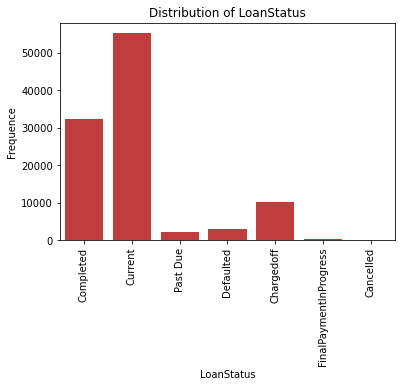

## Distribution of BorrowerAPR

The distribution of BorrowerAPR look as it's a multimodal shape.

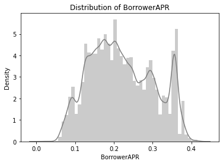

## LoanStatus Vs BorrowerAPR

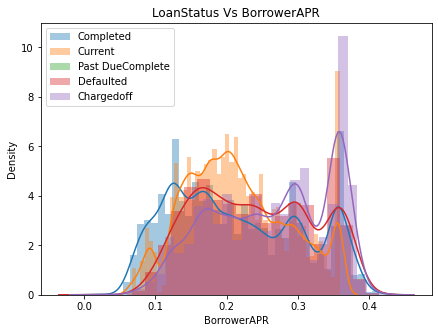

# LoanStatus vs EmploymentStatus

The multiple barchart of LoanStatuts regarding EmploymentStatus show us that the class **current** can be easyly recognise by nkowing the statut of employment (Emoloyed).

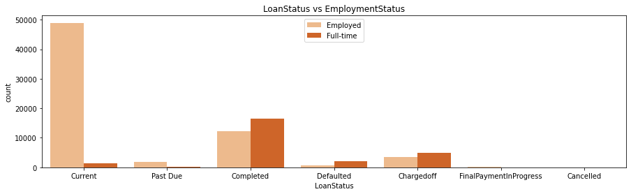

# LoanStatus Vs CurrentlyInGroup

here we can see that not belonging to a group makes it easy to distinguish the Current class. But here, we see that the other classes can also be fair. but with a lower degree of certainty.

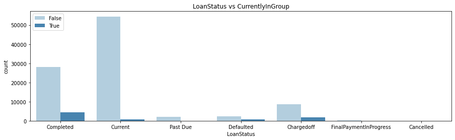